# Hypothesis testing in sensory analysis

Block 2 · exercises 5a – 5d

Sensometrics in R · SaIT

## The logic of a test

- **H₀**: there is no difference between the samples (assessors are only guessing)
- **H₁**: a difference exists
- **p-value**: how likely is the observed (or a more extreme) situation if H₀ holds

p < 0.05 → reject H₀. But p ≥ 0.05 does **not** mean the samples are the same – the panel may have been small (block 3).

## Which test for two samples?

| data type | situation | test in R |
| --- | --- | --- |
| continuous / scale | normal distribution | `t.test()` |
| continuous / scale | non-normal distribution | `wilcox.test()` |
| counts of correct answers | sample vs. chance (duo, triangle) | `binom.test()` |
| counts in categories | several categories (Likert, preferences) | `chisq.test()` |
| yes / no | the same people before / after | `mcnemar.test()` |

Paired (dependent) data = the same assessors rated both samples → `paired = TRUE`.

## Checking normality

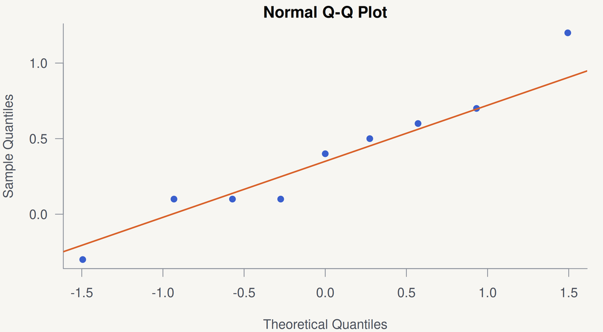

```r
B <- c(7.5, 8.1, 7.5, 7.4, 7.1, 7.5, 7.2, 7.2, 6.9)
E <- c(6.8, 6.9, 6.9, 7, 7, 7, 7.1, 7.1, 7.2)
difference <- B - E
qqnorm(difference, pch = 19, col = pal[3])
qqline(difference, col = pal[2], lwd = 2)
```

```r
shapiro.test(difference)$p.value
```

```
[1] 0.8074322
```

In the Shapiro-Wilk test H₀ is “the data are normal” → **p ≥ 0.05 is good news**. For paired data we test the normality of the **differences**.

## Paired t-test: cheese B vs. original E

```r
t.test(B, E, paired = TRUE)
```

```
    Paired t-test

data:  B and E
t = 2.5868, df = 8, p-value = 0.03227
alternative hypothesis: true mean difference is not equal to 0
95 percent confidence interval:
 0.04101305 0.71454251
sample estimates:
mean difference
      0.3777778
```

Cheese B is significantly better than the original (p = 0.032). The Wilcoxon test gives the same conclusion.

## Discrimination tests and the binomial test

| Test | samples | guessing probability |
| --- | --- | --- |
| paired, duo-trio | 2 (+ reference) | 1/2 |
| triangle, tetrad | 3 / 4 | 1/3 |

```r
binom.test(34, 60, p = 1 / 2)$p.value                                 # paired preference
```

```
[1] 0.366294
```

```r
binom.test(42, 100, p = 1 / 3, alternative = "greater")$p.value       # triangle
```

```
[1] 0.04337149
```

## Where does 34 of 60 lie?

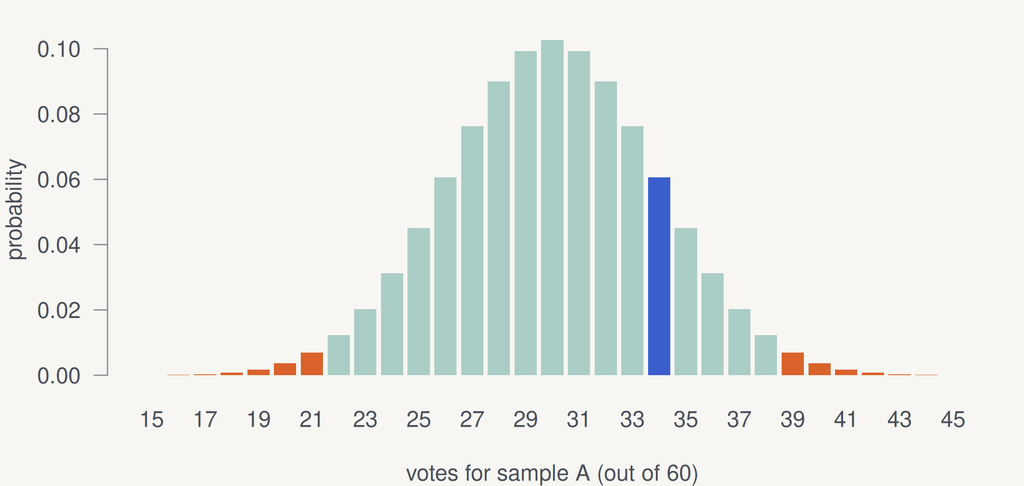

```r
k <- 15:45
colours <- ifelse(k >= 39 | k <= 21, pal[2], ifelse(k == 34, pal[3], "#0f7b6c55"))
barplot(dbinom(k, 60, 0.5), names.arg = k, col = colours, border = NA,
        xlab = "votes for sample A (out of 60)", ylab = "probability")
```

Orange = critical region (p < 0.05). The observed 34 (blue) is in the usual guessing region.

## χ² test and McNemar test

**Yogurt preference**

```r
chisq.test(c(25, 34, 17, 7))$p.value
```

```
[1] 0.0002581557
```

Preferences are not uniform.

**Old vs. new recipe**

```r
rum <- matrix(c(40, 8, 24, 28), nrow = 2)
mcnemar.test(rum, correct = FALSE)$p.value
```

```
[1] 0.004677735
```

Only those who changed their mind count (24 vs. 8).

## QUIZ Which test?

50 consumers tasted **both the old and the new** recipe and said for each whether they would buy it (yes/no). Which test shows whether the new recipe changed purchase intent?

**McNemar test** – the same people, a binary answer, before/after. A χ² test of independence would ignore the pairing.

## More than two samples

With 5 samples there are 10 pairs → with 10 t-tests the chance of a false alarm is about **40%**.

```r
round(1 - 0.95^c(1, 3, 6, 10), 2)
```

```
[1] 0.05 0.14 0.26 0.40
```

First **one global test** (ANOVA, Kruskal-Wallis, Friedman), only then **post-hoc** comparisons with a correction.

## ANOVA: between vs. within groups

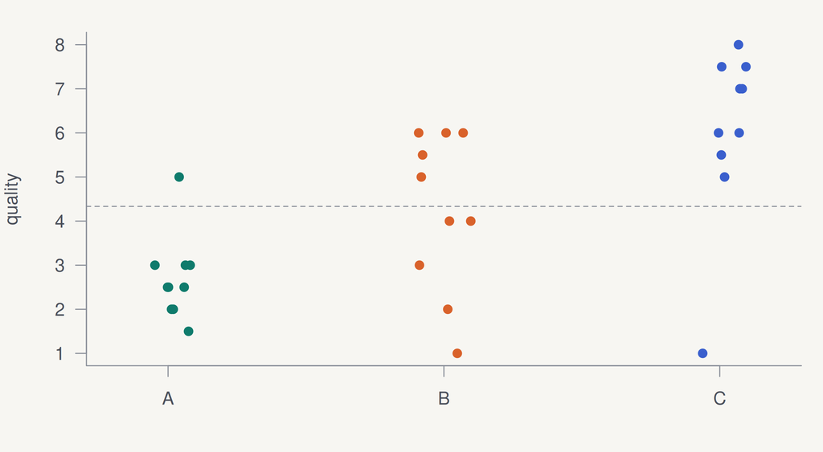

```r
chocolate <- data.frame(
  quality = c(1.5, 2, 2.5, 3, 2.5, 2.5, 3, 3, 2, 5,
              4, 3, 6, 5, 2, 6, 1, 6, 5.5, 4,
              6, 6, 7.5, 7, 5, 1, 8, 7, 7.5, 5.5),
  sample = factor(rep(c("A", "B", "C"), each = 10))
)
stripchart(quality ~ sample, data = chocolate,
           vertical = TRUE, method = "jitter",
           pch = 19, col = pal[1:3])
abline(h = mean(chocolate$quality), lty = 2)
```

F = variability between means / variability within groups.

## ANOVA and Kruskal-Wallis in R

```r
summary(aov(quality ~ sample, data = chocolate))
```

```
            Df Sum Sq Mean Sq F value   Pr(>F)
sample       2  56.22   28.11   10.33 0.000465 ***
Residuals   27  73.45    2.72
---
Signif. codes:  0 '***' 0.001 '**' 0.01 '*' 0.05 '.' 0.1 ' ' 1
```

```r
kruskal.test(quality ~ sample, data = chocolate)$p.value
```

```
[1] 0.002500272
```

In the formula the **measured value is on the left, the group on the right**: `quality ~ sample`. The reversed form gives a meaningless result.

## Post-hoc: which samples differ?

```r
TukeyHSD(aov(quality ~ sample, data = chocolate))$sample
```

```
    diff         lwr      upr        p adj
B-A 1.55 -0.27885263 3.378853 0.1084253376
C-A 3.35  1.52114737 5.178853 0.0002986978
C-B 1.80 -0.02885263 3.628853 0.0543663996
```

```r
pairwise.wilcox.test(chocolate$quality, chocolate$sample, p.adjust.method = "bonferroni", exact = FALSE)$p.value
```

```
            A          B
B 0.129673504         NA
C 0.009150466 0.08049856
```

## Blocks: Friedman and Durbin

- **Friedman** – every assessor (block) ranks **all** samples: `friedman.test(y ~ sample | assessor)`
- **Durbin** – every assessor gets only **part** of the samples according to a balanced plan (BIBD)

|  | A | B | C | D | E | F | G |
| --- | --- | --- | --- | --- | --- | --- | --- |
| H1 | 2 | 3 |  | 1 |  |  |  |
| H2 |  | 3 | 1 |  | 2 |  |  |
| H3 |  |  | 2 | 1 |  | 3 |  |
| H4 |  |  |  | 1 | 2 |  | 3 |
| H5 | 3 |  |  |  | 1 | 2 |  |
| H6 |  | 3 |  |  |  | 1 | 2 |
| H7 | 3 |  | 1 |  |  |  | 2 |

7 samples, each assessor tastes 3, every pair of samples meets exactly once.

## QUIZ Independent or blocks?

4 ketchups were rated by 13 assessors **in one session** – each tasted all 4. The ratings are not normal. Which test?

**Friedman test** – the assessor is a block (everyone rated everything) and the data are not normal. Kruskal-Wallis would ignore that these are the same people.

## Summary

- First the **design**: paired / independent, two / more samples, blocks.
- Then the **assumptions**: normality (plot + test).
- **One global test**, then post-hoc with a correction.
- Discrimination tests: the binomial test with a guessing probability of 1/2 or 1/3.

Theory 5a Theory 5b Theory 5c Theory 5d